# Entrance, duration of contracts, accumulated experience

Adam Finnemann

October 19, 2017

## Question: For each year, how long does a person stay in the section?

First calculation: Subtracting end year of contract from beginning year. Take the average of this measure for each year and plot it per year. Here it’s assumed that all contracts start and end on the first 1. januar. In other words, only information about year differences is used.

```r
#why mutate no work??
da$begin_date <- as.Date(as.character(da$begin_date))
da$end_date <- as.Date(as.character(da$end_date))


da <-da  %>%
  mutate(duration = end_date - begin_date)
```

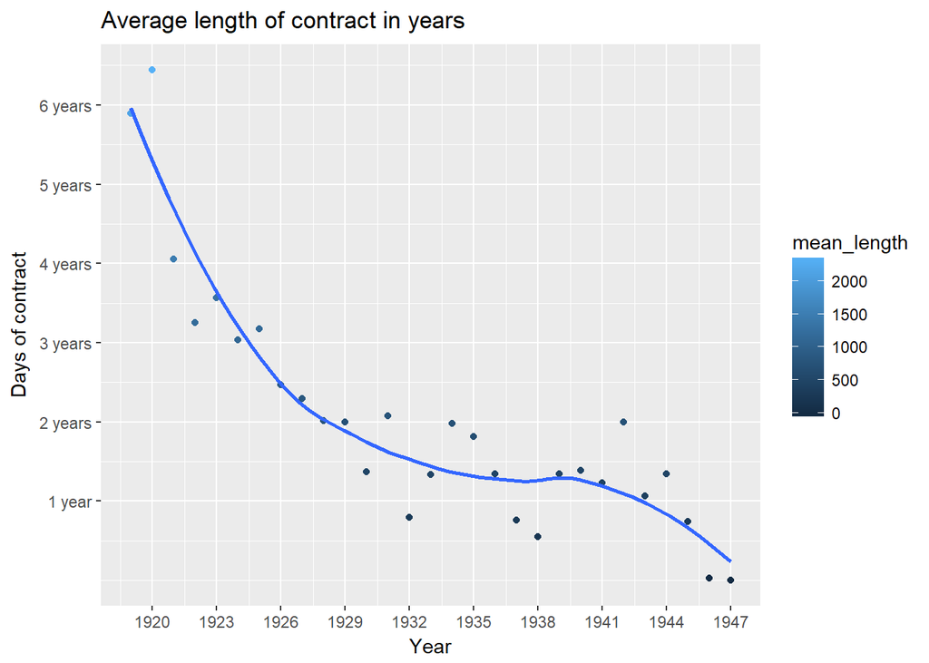

```r
da$begin_date <- as.factor(da$begin_date)
da$duration <- as.numeric(da$duration)
contract_length_per_year <- da %>%
  group_by(begin_date) %>%
  summarise(mean_length = mean(duration))


contract_length_per_year$begin_date <- as.Date(contract_length_per_year$begin_date)

contract_length_per_year %>%
  ggplot(aes(begin_date,mean_length, color = mean_length)) +
  geom_point() +
  geom_smooth(se = F) +
  labs(x = "Year", y ="Days of contract", titles = "Average length of contract in years")+
  scale_x_date(date_breaks = "3 year", date_labels = "%Y")+
  scale_y_continuous(breaks = c(365, 365*2, 365*3, 365*4, 365*5, 365*6),labels = c("1 year", "2 years","3 years","4 years","5 years","6 years") )
```

```r
#employment interval function
employment <- function(df, interval = "1 year"){

mdl_df <- df %>%
  select(pname, fname_code,begin_date, end_date) %>%
  mutate(begin_date = as.Date(begin_date),
         end_date = as.Date(end_date))



result <- setDT(mdl_df)[
  .(mseq = seq(as.Date("1919-01-01"), as.Date("1948-12-30"), by = interval)),
  on = .(begin_date <= mseq, end_date >= mseq), nomatch = 0L, allow.cartesian = TRUE][
    , dcast(unique(.SD), pname ~ end_date, toString, value.var = "fname_code")]
}

res <-employment(da)
```

For each person, two measures are made: Number of years before they were employed, and the number of consecutive years their first employment period lasted. If a new contract starts the same year as the old one expires it’s counted as consecutive. In other words, the second contract has to start in a different year than the first one expires. This means that up to 11 month long breaks can be counted as consecutive periods.

Finally, for each year the average employment period of first time workers is calculated and visualized.

```r
wo_pname = res[,-1]
results <- matrix(NA, nrow = nrow(wo_pname), 2)

for (i in 1:nrow(wo_pname)) {
  count = 1
  blank = 0
  non_blank = 0
  new_blank = 0
  #while cells are blank add 1 to blank and counter
  while(wo_pname[i,count, with =F] =="") {
      blank = blank + 1
      count = count + 1
  }
    #if no new blanks and the current cell isn't empty
    while(wo_pname[i,count, with = F] != ""){
      non_blank = non_blank + 1
      count = count + 1
    }
  results[i,] <- c(blank, non_blank)
  }
```

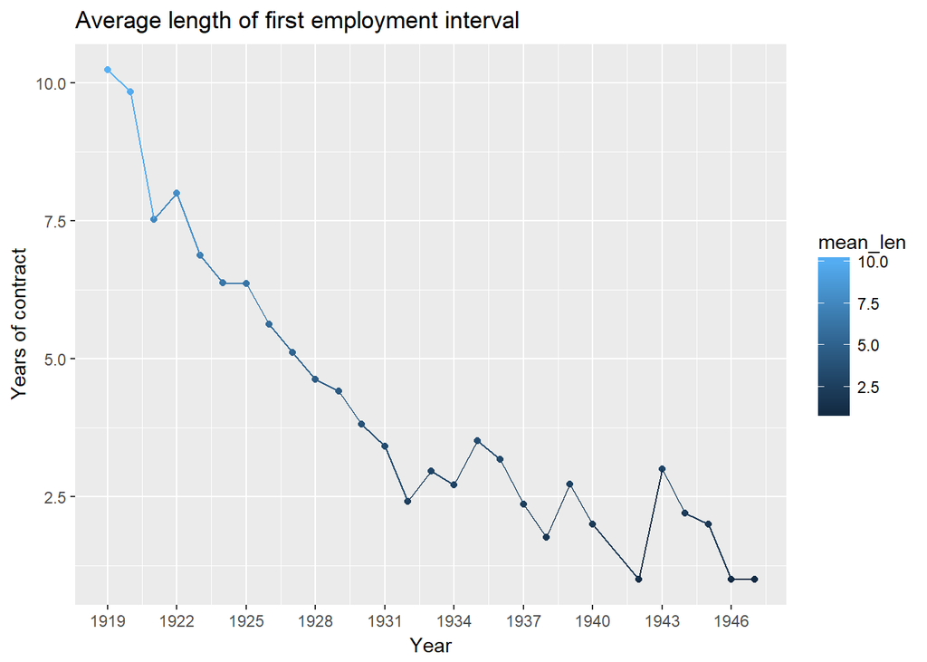

```r
colnames(results) <- c("blanks","non_blank")

df <- results %>%
  as.data.frame() %>%
  mutate(pname = res$pname,
         begin_year = blanks + 1919,
         end_year = 1919 + blanks + non_blank,
         duration = end_year - begin_year)

avg_len <- df %>%
  group_by(begin_year) %>%
  summarise(mean_len = mean(duration))

avg_len %>%
  ggplot(aes(begin_year, mean_len, color = mean_len)) +
  geom_point()+
  geom_line()+
  labs(x = "Year", y ="Years of contract", titles = "Average length of first employment interval")+
  scale_x_continuous(breaks = seq(1919,1948,3))
```

Subsetting scandinavian people and repeating plot

```r
summary(da$nationality)
```

```
##                                    Albanian         AlbanianSwiss
##                   346                     5                     3
##           Argentinian              Armenian            Australian
##                     8                     2                    24
##              Austrian              Bolivian             Brazilian
##                    44                     3                     3
##               British          BritishSwiss             Bulgarian
##                   390                     1                    15
##              Canadian               Chilean               Chinese
##                    26                     4                    22
##           Costa_Rican                 Cuban                 Czech
##                     3                     4                    43
##                  Dane              Danziger                 Dutch
##                    41                     2                    61
##            DutchSwiss              Egyptian               English
##                     1                     4                  1012
##          English,Dane   English,US-American              Estonian
##                     1                     2                     7
##                Finish                French French,British, Swiss
##                    12                   978                     1
##        French,Italian           FrenchSwiss                German
##                     1                     1                   101
##                 Greek            Guatemalan               Haitian
##                    27                     2                     1
##             Hungarian             Icelander                Indian
##                    27                     2                    43
##               Iranian                 Iraqi                 Irish
##                     7                     6                    55
##               Italian       Italian,English          ItalianSwiss
##                   297                     1                     6
##              Japanese               Latvian          LatvianSwiss
##                     4                    13                     1
##            Lithuanian         Luxembourgish               Mexican
##                    14                    13                     4
##         New_Zealander             Norwegian            Panamanian
##                    14                    34                     3
##            Paraguayan               Persian              Peruvian
##                     2                     3                     8
##                Polish             Portugese              Romanian
##                    59                     9                    25
##               Russian       Russian,British          RussianSwiss
##                    21                     1                     2
##           Salvadorian               Siamese         South_African
##                     1                     2                    12
##               Spanish               Swedish                 Swiss
##                    32                    30                  2297
##        Swiss,Armenian         Swiss,British         Swiss,English
##                     5                    13                     8
##          Swiss,French          Swiss,German          Swiss,Syrian
##                     6                     1                     1
##        Swiss,Yugoslav                Syrian                  Thai
##                     1                     1                     1
##               Turkish             Uruguayan           US-American
##                     8                     3                    61
##            Venezuelan              Yugoslav
##                     6                    36
```

```r
scandi <- da %>%
  filter(nationality %in% c("Dane","Swedish","Norwegian"))
```

105 contract belonging to Scandinavians are found

```r
scandi_res <- employment(scandi)
wo_pname_scandi = scandi_res[,-1]
scandi_results <- matrix(NA, nrow = nrow(wo_pname_scandi), 2)

for (i in 1:nrow(wo_pname_scandi)) {
  count = 1
  blank = 0
  non_blank = 0
  new_blank = 0
  #while cells are blank add 1 to blank and counter
  while(wo_pname_scandi[i,count, with =F] =="") {
      blank = blank + 1
      count = count + 1

  }
    #if no new blanks and the current cell isn't empty
    while((wo_pname_scandi[i,count, with = F] != "") & count < ncol(wo_pname_scandi)-1){
      non_blank = non_blank + 1
      count = count + 1
        }

  scandi_results[i,] <- c(blank, non_blank)
}
```

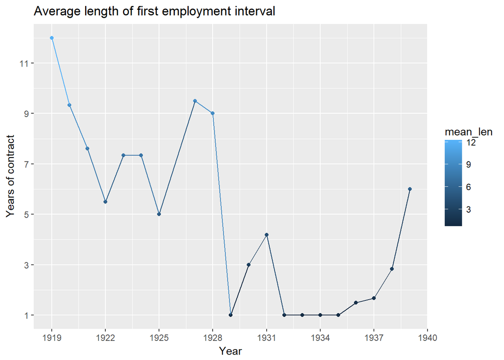

```r
colnames(scandi_results) <- c("blanks","non_blank")

df <- scandi_results %>%
  as.data.frame() %>%
  mutate(pname = scandi_res$pname,
         begin_year = blanks + 1919,
         end_year = 1919 + blanks + non_blank,
         duration = end_year - begin_year)

avg_len <- df %>%
  group_by(begin_year) %>%
  summarise(mean_len = mean(duration))

avg_len %>%
  ggplot(aes(begin_year, mean_len, color = mean_len)) +
  geom_point()+
  geom_line()+
  labs(x = "Year", y ="Years of contract", titles = "Average length of first employment interval")+
  scale_x_continuous(breaks = seq(1919,1948,3))+
  scale_y_continuous(breaks = seq(1,12,2))
```

Visualizing number of first time contracts per year for Scandinavians

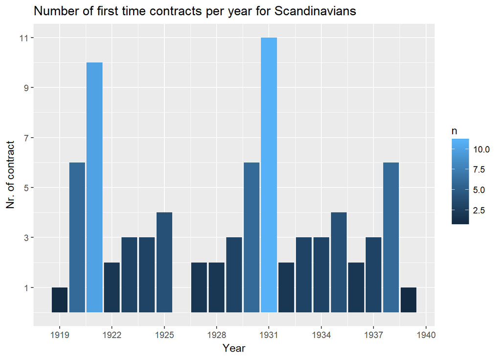

```r
df %>%
  group_by(begin_year) %>%
  tally() %>%
  ggplot(aes(begin_year, n, fill = n)) +
  geom_col() +
  labs(x = "Year", y ="Nr. of contract", titles = "Number of first time contracts per year for Scandinavians")+
  scale_x_continuous(breaks = seq(1919,1948,3))+
  scale_y_continuous(breaks = seq(1,12,2))
```

Further subset, including only Scandinavians in Section and director

```r
top_scandi <- scandi %>%
  filter(str_detect(scandi$fname, "Section") | str_detect(scandi$fname, "Director"),
         fname != "Secretary of Section")
unique(droplevels(top_scandi$pname))
```

```
##  [1] Bertil Gotthard Ohlin             Christian Olsen
##  [3] Peter Martin Anker                Oscar Uno Konrad Thorsing
##  [5] Peter Christian Schou             Essy HjÃ¶rdis Lehmann
##  [7] John Lindberg                     Ludwig Thorwald de Krabbe
##  [9] Per Jacobsson                     Erik Andreas Colban
## [11] Ãke  HammarskjÃ¶ld               Erik Einan Ekstrand
## [13] Bertil Arne Renborg               Finn Tage Blichfeldt Friis
## [15] Johan Ansgar Esaias Rosenborg     Helmer Rostgaard Gommesen Rosting
## [17] Dr. Knud Stouman                  Karen Petersen
## [19] Rasmus Ingvald Berentson Skylstad
## 19 Levels: Ãke  HammarskjÃ¶ld ... Rasmus Ingvald Berentson Skylstad
```

This includes 24 contracts from 19 different people

```r
scandi_res <- employment(top_scandi)
```

```r
p <- top_scandi[which(!top_scandi$pname %in% scandi_res$pname),]
p
```

```
##   X.1    X   id                     pname gender             fname
## 5 267 6406 5042 Oscar Uno Konrad Thorsing      0 Member of Section
##   canonical_fname               oname born_on_year begin_on_year
## 5  First Division Information Section         1896          1925
##   begin_on_month begin_on_day end_on_year end_on_month end_on_day
## 5             10            1        1924           12         31
##   nationality fname_code begin_date   end_date duration
## 5     Swedish          8 1925-01-01 1924-01-01     -366
```

One contract is removed in the analysis: reason: begin_on_year is later than his end_on_year.

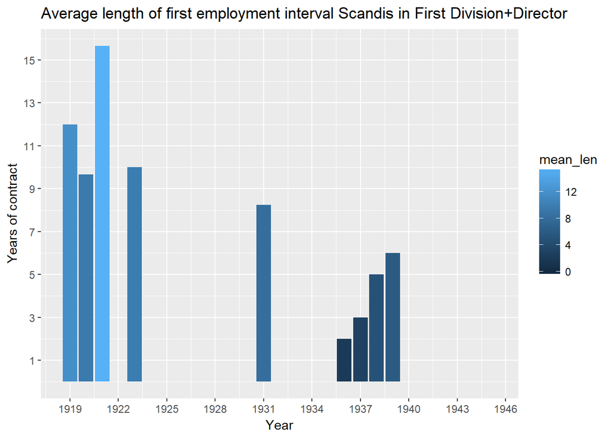

```r
wo_pname_scandi = scandi_res[,-1]
scandi_results <- matrix(NA, nrow = nrow(wo_pname_scandi), 2)

for (i in 1:nrow(wo_pname_scandi)) {
  count = 1
  blank = 0
  non_blank = 0
  new_blank = 0
  #while cells are blank add 1 to blank and counter
  while(wo_pname_scandi[i,count, with =F] =="") {
      blank = blank + 1
      count = count + 1

  }
    #if no new blanks and the current cell isn't empty
    while((wo_pname_scandi[i,count, with = F] != "") & count < ncol(wo_pname_scandi)-1){
      non_blank = non_blank + 1
      count = count + 1
        }

  scandi_results[i,] <- c(blank, non_blank)
}
colnames(scandi_results) <- c("blanks","non_blank")

df <- scandi_results %>%
  as.data.frame() %>%
  mutate(pname = scandi_res$pname,
         begin_year = blanks + 1919,
         end_year = 1919 + blanks + non_blank,
         duration = end_year - begin_year)

avg_len <- df %>%
  group_by(begin_year) %>%
  summarise(mean_len = mean(duration))

avg_len %>%
  ggplot(aes(begin_year, mean_len, fill = mean_len)) +
  geom_col() +
  labs(x = "Year", y ="Years of contract", titles = "Average length of first employment interval Scandis in First Division+Director")+
  scale_x_continuous(breaks = seq(1919,1948,3))+
  scale_y_continuous(breaks = seq(1,15,2))
```

Visualization number of contracts per year

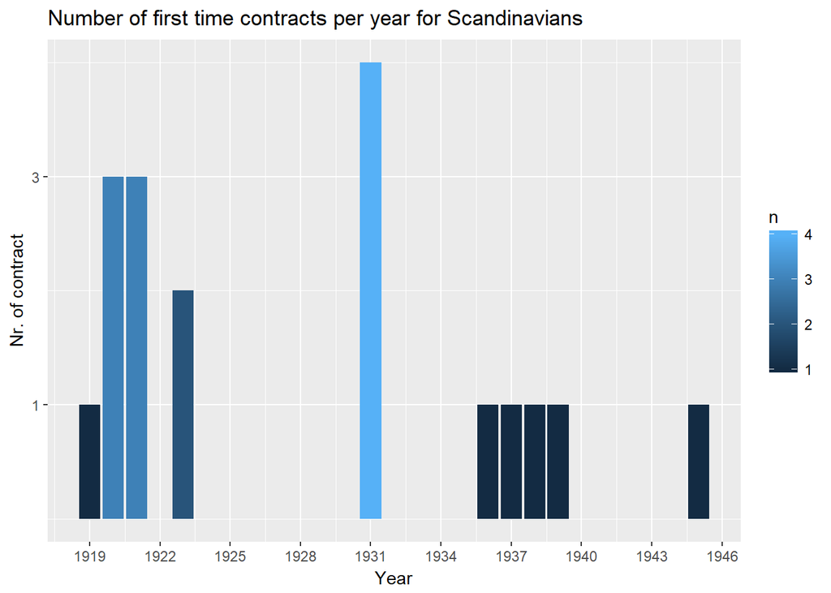

```r
df %>%
  group_by(begin_year) %>%
  tally() %>%
  ggplot(aes(begin_year, n, fill = n)) +
  geom_col() +
  labs(x = "Year", y ="Nr. of contract", titles = "Number of first time contracts per year for Scandinavians")+
  scale_x_continuous(breaks = seq(1919,1948,3))+
  scale_y_continuous(breaks = seq(1,12,2))
```

# New question: How many Scandinavians were there in section/directors over time:

```r
mdl_df <- top_scandi %>%
  select(pname, fname_code,begin_date, end_date) %>%
  mutate(begin_date = as.Date(begin_date),
         end_date = as.Date(end_date))



result <- setDT(mdl_df)[
  .(mseq = seq(as.Date("1919-01-01"), as.Date("1948-12-30"), by = "1 year")),
  on = .(begin_date <= mseq, end_date >= mseq), nomatch = 0L, allow.cartesian = TRUE][
    , dcast(unique(.SD), pname ~ end_date, toString, value.var = "fname_code")]

scandi_workers <- result%>%
  summarise_all(function(x) sum(x != ""))

long_df <- gather(scandi_workers, key, value, `1919-01-01`:`1946-01-01`) %>%
  mutate(key = as.Date(key))


str(long_df)
```

```
## 'data.frame':    28 obs. of  3 variables:
##  $ pname: int  18 18 18 18 18 18 18 18 18 18 ...
##  $ key  : Date, format: "1919-01-01" "1920-01-01" ...
##  $ value: int  1 4 7 7 8 8 7 7 7 7 ...
```

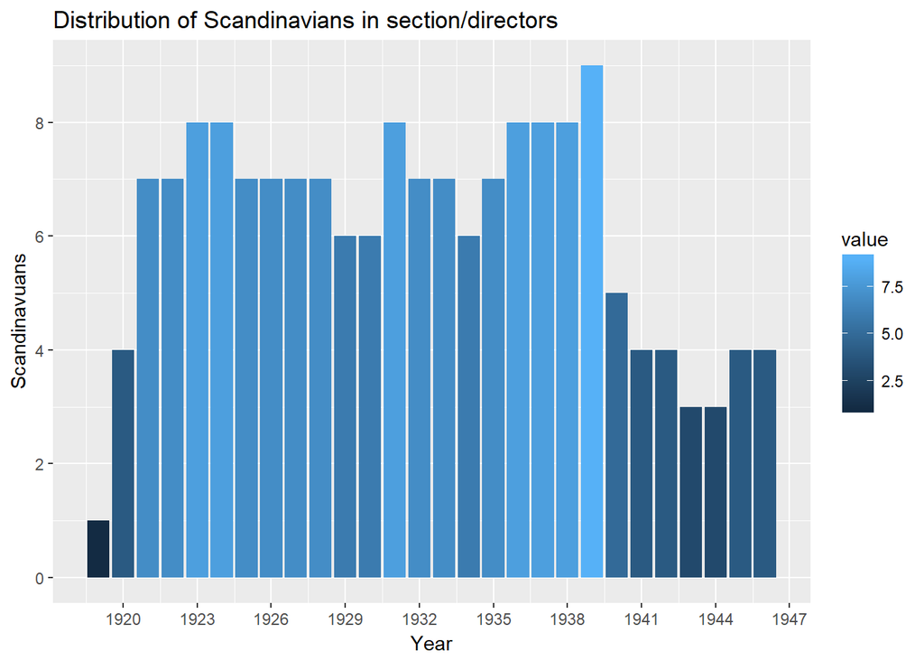

```r
 long_df %>%
  ggplot(aes(x = key, y = value, fill = value)) +
  geom_col() +
  scale_x_date(date_breaks = "3 year", date_labels = "%Y") +
  scale_y_continuous(breaks = seq(0,12,2))+
  labs(x = "Year", y ="Scandinavuans", titles = "Distribution of Scandinavians in section/directors")
```

Years with more than 7 Scandinavians in Section/director

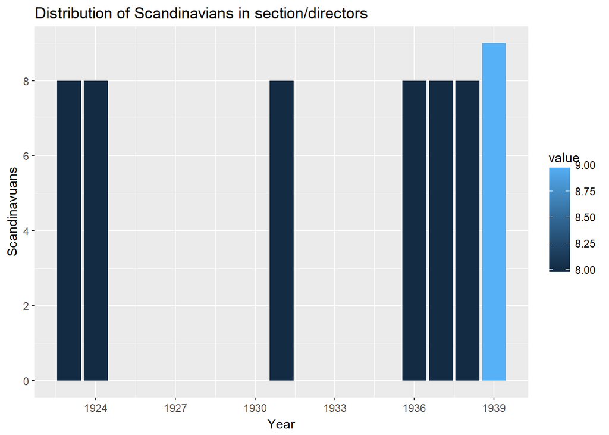

```r
long_df %>%
  filter(value > 7) %>%
  ggplot(aes(x = key, y = value, fill = value)) +
  geom_col() +
  scale_x_date(date_breaks = "3 year", date_labels = "%Y") +
  scale_y_continuous(breaks = seq(0,12,2))+
  labs(x = "Year", y ="Scandinavuans", titles = "Distribution of Scandinavians in section/directors")
```

## New question: What is the average years of employment (in total) per worker.

Decisions made: all years where a worked was present in LoN is counted (across breaks). Years are counted inclusively, so an employment period from 21 to 46 will give a total of 26 years on LoN.

defining function:

```r
employment_distribution <- function(df, xseq = seq(0,30,5),yseq = seq(0,2000, 250), group = "people"){
result <- employment(df)

contract_length <- matrix(nrow = (nrow(result)), ncol = 1)

result <- as.data.frame(result)

names <- as.character(result[,1])

#removing pname column
contracts<- sapply(result[,-1],function(x) x != "") %>%
  rowSums() %>%
  as.data.frame() %>%
  rename(contract_length = ".") %>%
  mutate(names = as.factor(names))


contracts %>%
  ggplot(aes(contract_length, color = contract_length)) +
  geom_histogram(binwidth = 1, aes(fill = ..count..)) +
  scale_fill_gradient("count", low="orange", high="purple") +
  labs(x = "Work periods in years", y = "Number of people", title = paste("Distribution of work periods in LoN for",group)) +
  scale_x_continuous(breaks = xseq)+
  scale_y_continuous(breaks = yseq)
}
```

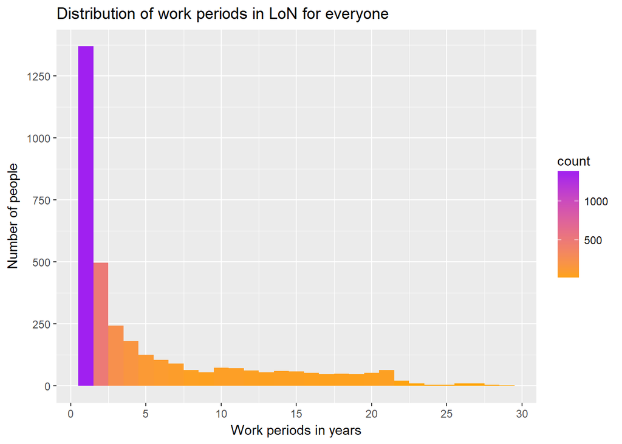

```r
employment_distribution(da, group = "everyone")
```

repeating analysis for all scandinavians

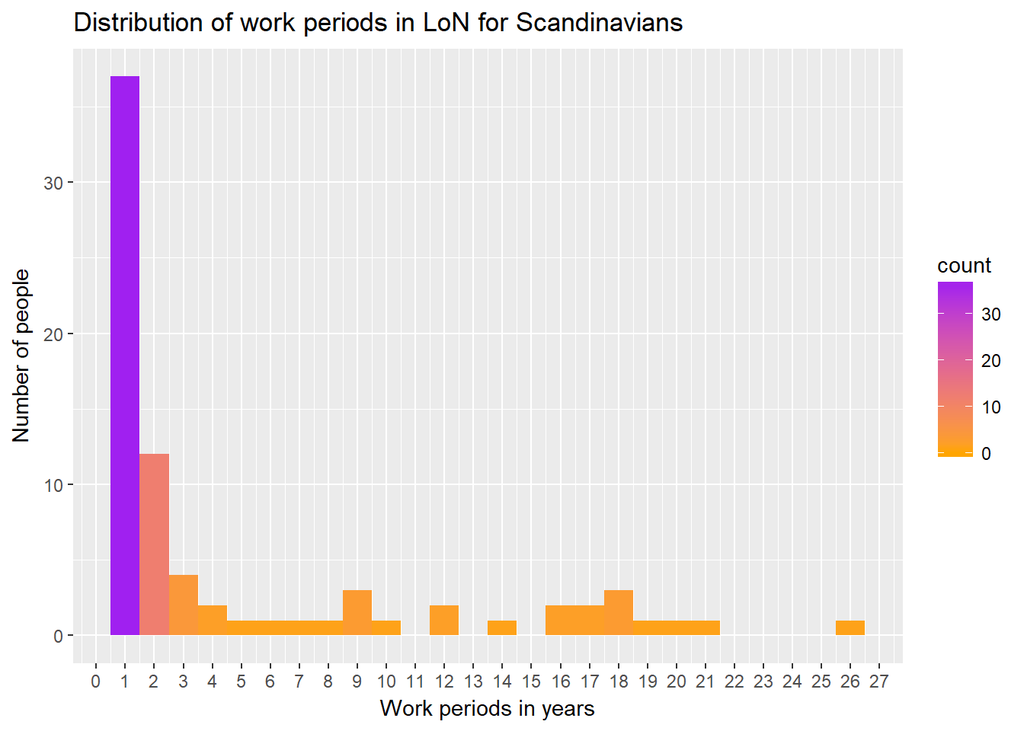

```r
employment_distribution(scandi,xseq = seq(0,30,1), yseq = seq(0,1500,10), group ="Scandinavians")
```

Repeating analysis for scandinavians in First division

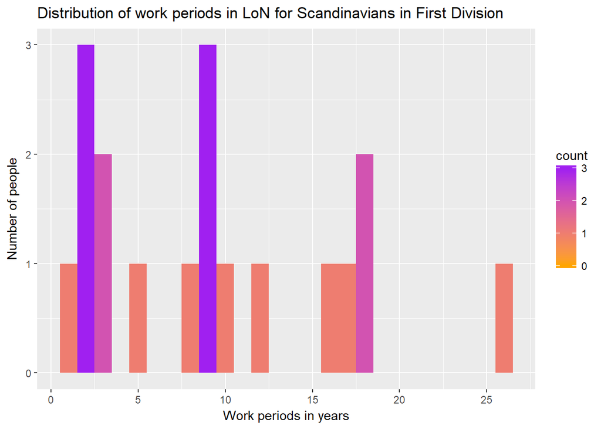

```r
employment_distribution(top_scandi, yseq = seq(0,3,1), group = "Scandinavians in First Division")
```

Same analysis for full section and each section + directors:

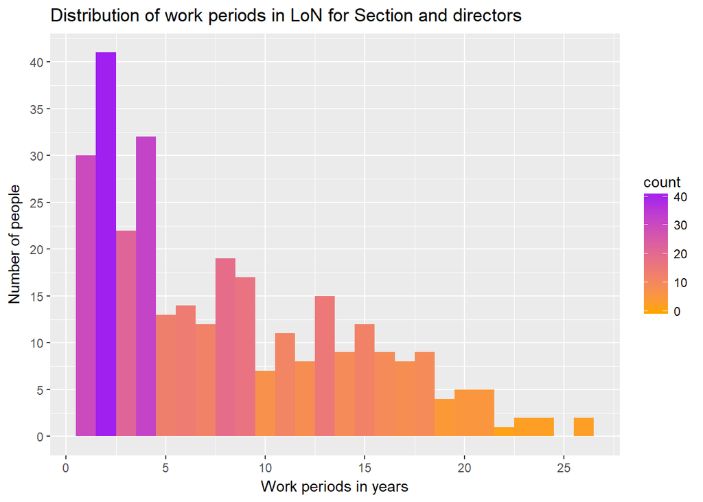

```r
section_da <- da%>%
filter(str_detect(da$fname, "Section") | str_detect(da$fname, "Director"),
         fname != "Secretary of Section")

employment_distribution(section_da, yseq = seq(0,100,5), group = "Section and directors")
```

Further analysis of each section is carried out on section with more than 10 total contracts. These are roughly: health, disarmament, mandates, legal, communications and transit, information, economic and financial section (which goes together with the economic relations section and the financial & economic intelligence service), intellectual cooperation and international bureaux section, minorities (which go together with Administrative and Minorities), the social questions and opium traffic, and the political section

First the three economic sections are united to 1. Same for “Minorities” and “Admin. and Minotories”.

```r
oname_correct <- section_da %>%
  mutate(oname = str_replace_all(oname, "Financial Section & Economic Intelligence Service","Economic and Financial Section"),
        oname = str_replace_all(oname, "Economic Relations Section","Economic and Financial Section")
         ) %>%
  mutate(oname = as.factor(oname),
         oname = recode(oname, "Minorities Section" = "Administrative and Minorities Section"))





large_sections <- oname_correct %>%
  group_by(oname) %>%
  filter(n() >10) %>%
  ungroup() %>%
  mutate(oname = droplevels(oname))
summary(large_sections$oname)
```

```
##                      Administrative and Minorities Section
##                                                         24
##                         Communications and Transit Section
##                                                         14
##                                        Disarmament Section
##                                                         19
##                                  Distribution of Documents
##                                                         13
##                             Economic and Financial Section
##                                                         68
##                                             Health Section
##                                                         46
##                                        Information Section
##                                                         58
## Intellectual Cooperation and International Bureaux Section
##                                                         11
##                                              Legal Section
##                                                         33
##                                           Mandates Section
##                                                         15
##                                          Political Section
##                                                         31
##                 Social Questions and Opium Traffic Section
##                                                         22
```

Keeping only large sections reduces number of contracts in analysis from 422 to 354.

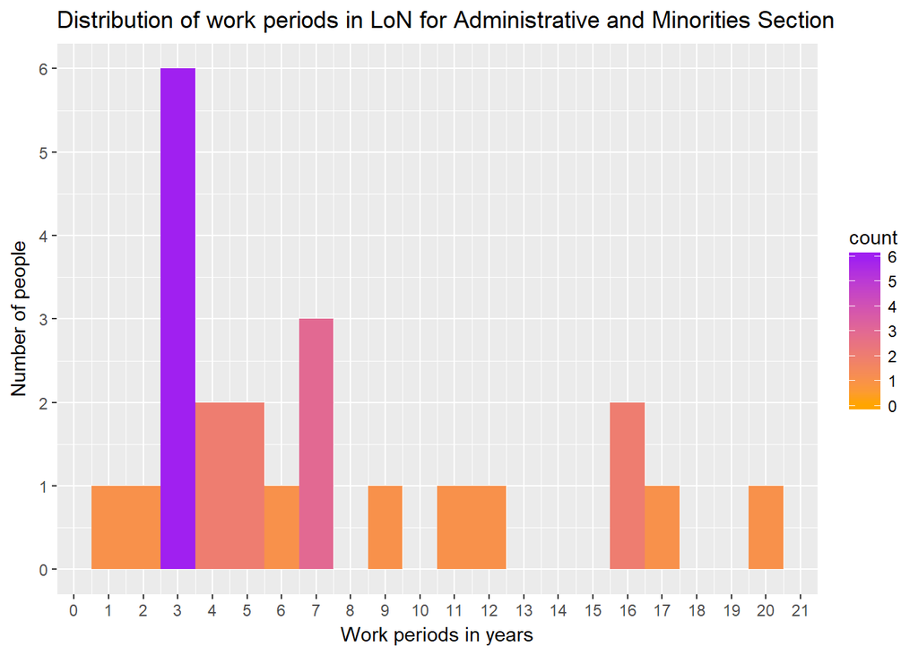

```r
employment_distribution(filter(large_sections, oname == levels(oname)[1]),xseq = seq(0,30,1), yseq = seq(0,100,1), group = levels(large_sections$oname)[1])
```

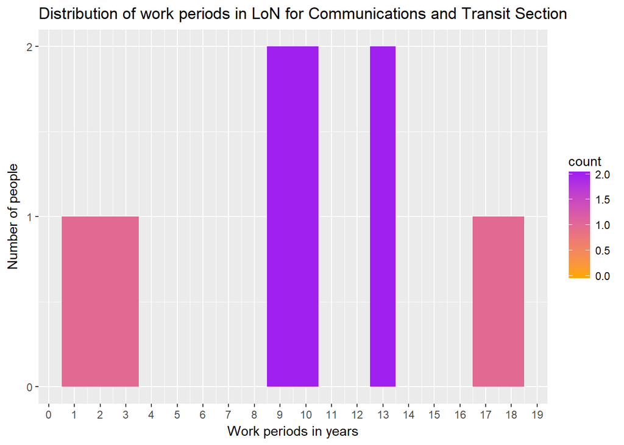

```r
employment_distribution(filter(large_sections, oname == levels(oname)[2]),xseq = seq(0,30,1), yseq = seq(0,100,1), group = levels(large_sections$oname)[2])
```

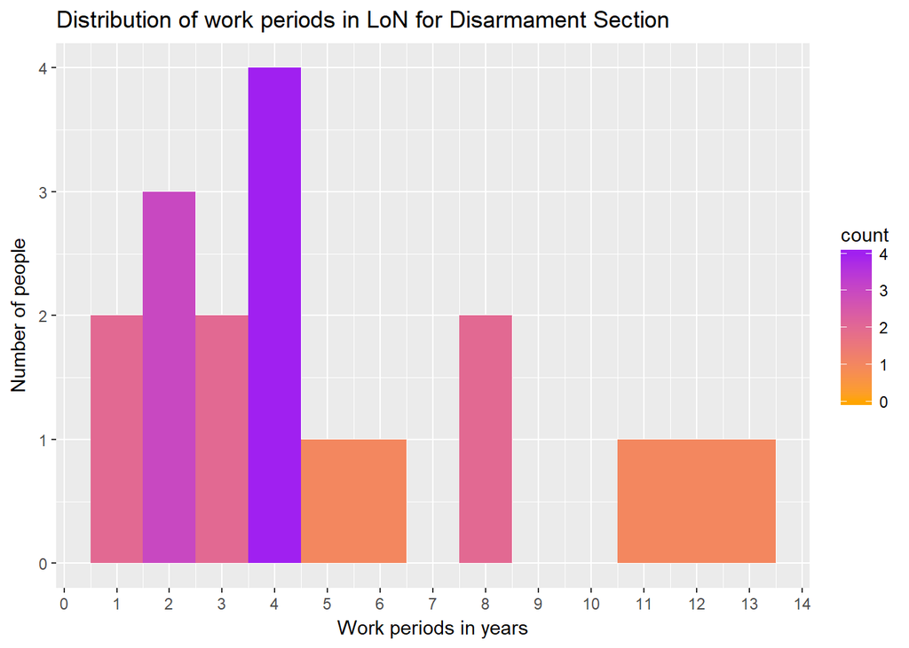

```r
employment_distribution(filter(large_sections, oname == levels(oname)[3]),xseq = seq(0,30,1), yseq = seq(0,100,1), group = levels(large_sections$oname)[3])
```

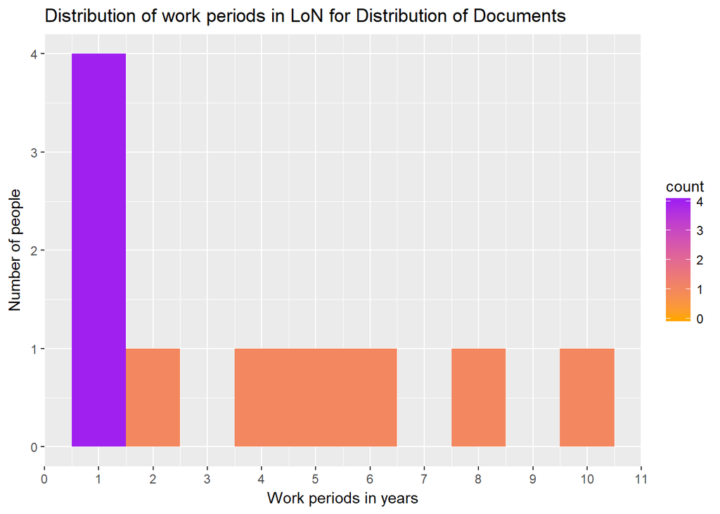

```r
employment_distribution(filter(large_sections, oname == levels(oname)[4]),xseq = seq(0,30,1), yseq = seq(0,100,1), group = levels(large_sections$oname)[4])
```

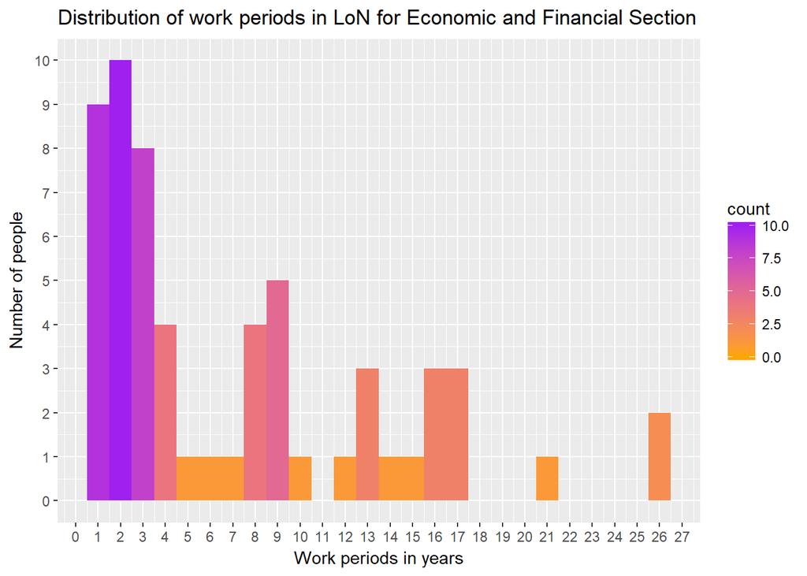

```r
employment_distribution(filter(large_sections, oname == levels(oname)[5]),xseq = seq(0,30,1), yseq = seq(0,100,1), group = levels(large_sections$oname)[5])
```

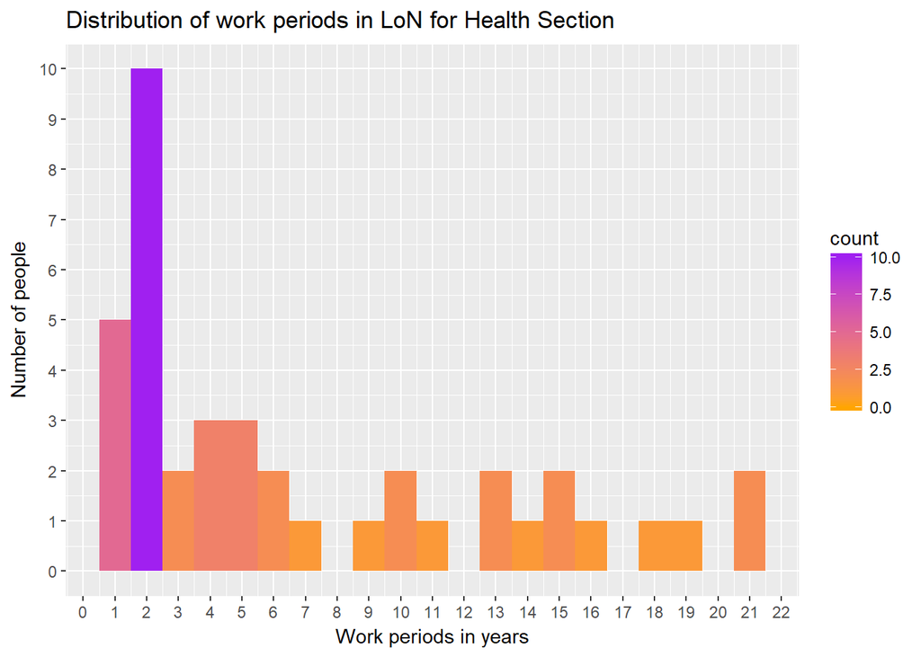

```r
employment_distribution(filter(large_sections, oname == levels(oname)[6]),xseq = seq(0,30,1), yseq = seq(0,100,1), group = levels(large_sections$oname)[6])
```

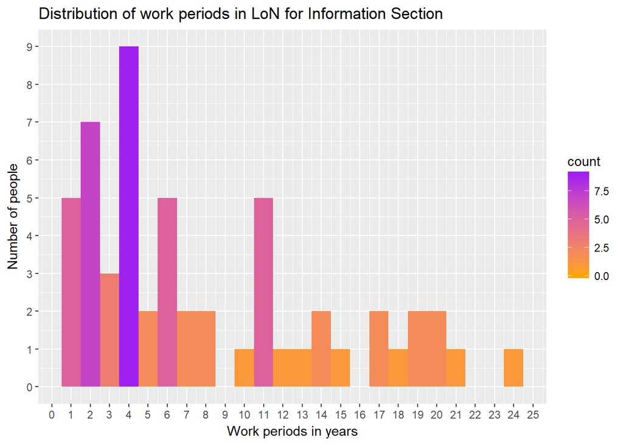

```r
employment_distribution(filter(large_sections, oname == levels(oname)[7]),xseq = seq(0,30,1), yseq = seq(0,100,1), group = levels(large_sections$oname)[7])
```

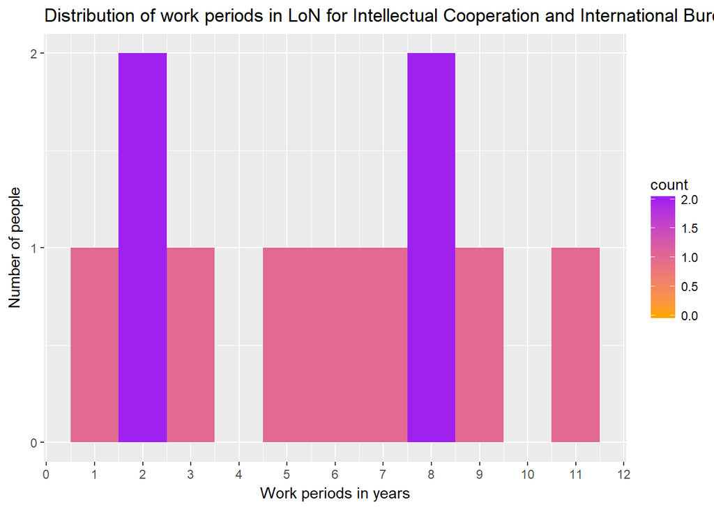

```r
employment_distribution(filter(large_sections, oname == levels(oname)[8]),xseq = seq(0,30,1), yseq = seq(0,100,1), group = levels(large_sections$oname)[8])
```

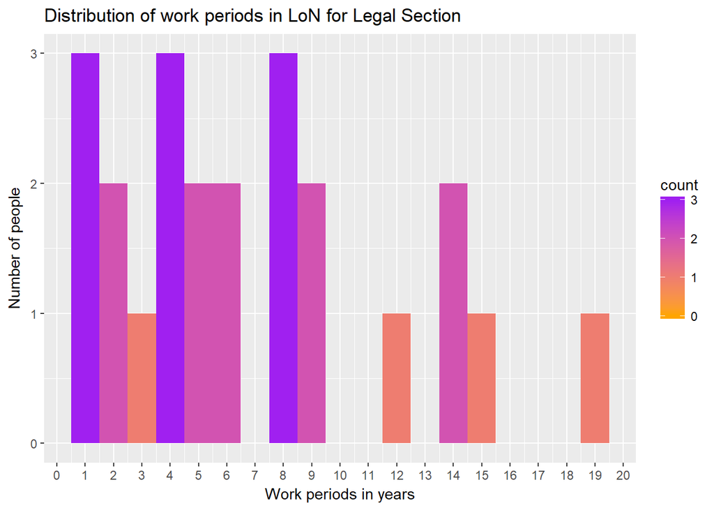

```r
employment_distribution(filter(large_sections, oname == levels(oname)[9]),xseq = seq(0,30,1), yseq = seq(0,100,1), group = levels(large_sections$oname)[9])
```

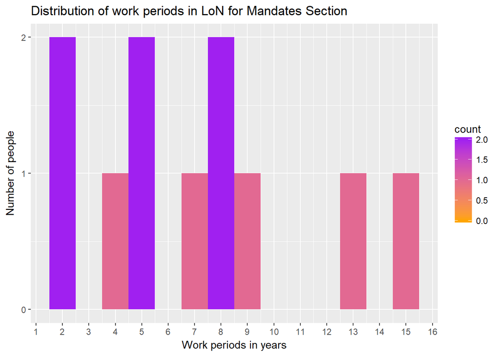

```r
employment_distribution(filter(large_sections, oname == levels(oname)[10]),xseq = seq(0,30,1), yseq = seq(0,100,1), group = levels(large_sections$oname)[10])
```

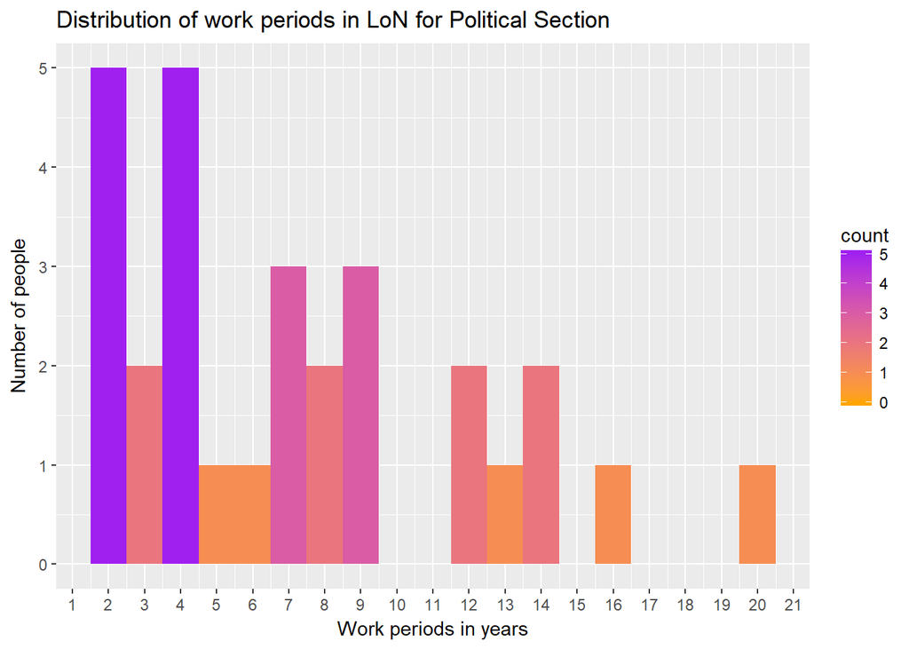

```r
employment_distribution(filter(large_sections, oname == levels(oname)[11]),xseq = seq(0,30,1), yseq = seq(0,100,1), group = levels(large_sections$oname)[11])
```

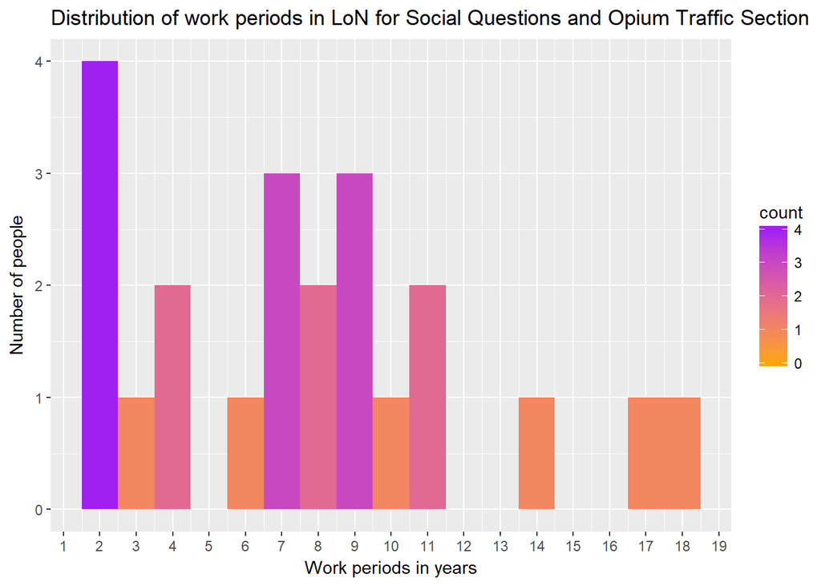

```r
employment_distribution(filter(large_sections, oname == levels(oname)[12]),xseq = seq(0,30,1), yseq = seq(0,100,1), group = levels(large_sections$oname)[12])
```

```r
five_nat.df <- da
five_nat.df$nationality <-str_replace_all(five_nat.df$nationality,"Dane", "Scandinavian")
five_nat.df$nationality <-str_replace_all(five_nat.df$nationality,"Swedish", "Scandinavian")
five_nat.df$nationality <-str_replace_all(five_nat.df$nationality,"Norwegian", "Scandinavian")
five_nat.df$nationality <-str_replace_all(five_nat.df$nationality,"Brazilian\t", "South American")
five_nat.df$nationality <-str_replace_all(five_nat.df$nationality,"Uruguayan", "South American")
five_nat.df$nationality <-str_replace_all(five_nat.df$nationality,"Peruvian", "South American")
five_nat.df$nationality <-str_replace_all(five_nat.df$nationality,"Argentinian", "South American")
five_nat.df$nationality <-str_replace_all(five_nat.df$nationality,"Chilean", "South American")
five_nat.df$nationality <-str_replace_all(five_nat.df$nationality,"Venezuelan\t", "South American")
five_nat.df$nationality <-str_replace_all(five_nat.df$nationality,"Paraguayan", "South American")
five_nat.df$nationality <-str_replace_all(five_nat.df$nationality,"Ecuadorian", "South American")
five_nat.df$nationality <-str_replace_all(five_nat.df$nationality,"Bolivian", "South American")
five_nat.df$nationality <-str_replace_all(five_nat.df$nationality,"English", "British")


five_nats <- five_nat.df %>%
  filter(nationality == "British"|nationality == "South American"| nationality == "Scandinavian"| nationality == "Swiss"| nationality == "French") %>%
  mutate(nationality = as.factor(nationality))
```

For all 5 nationalities

[figure not shown]

```r
employment_distribution(five_nats,xseq = seq(0,30,1), yseq = seq(0,1500,100), group = levels(large_sections$oname)[12])
```

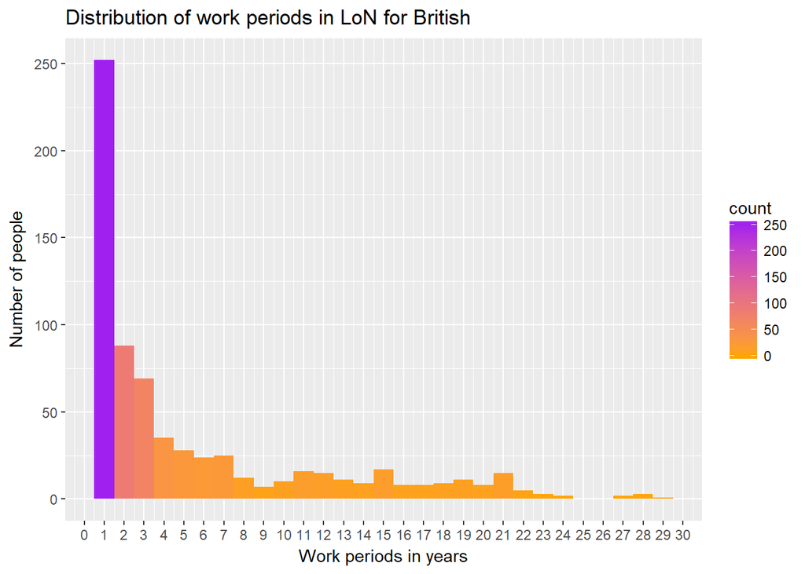

```r
employment_distribution(filter(five_nats, nationality == levels(nationality)[1]),xseq = seq(0,30,1), yseq = seq(0,1500,50), group = levels(five_nats$nationality)[1])
```

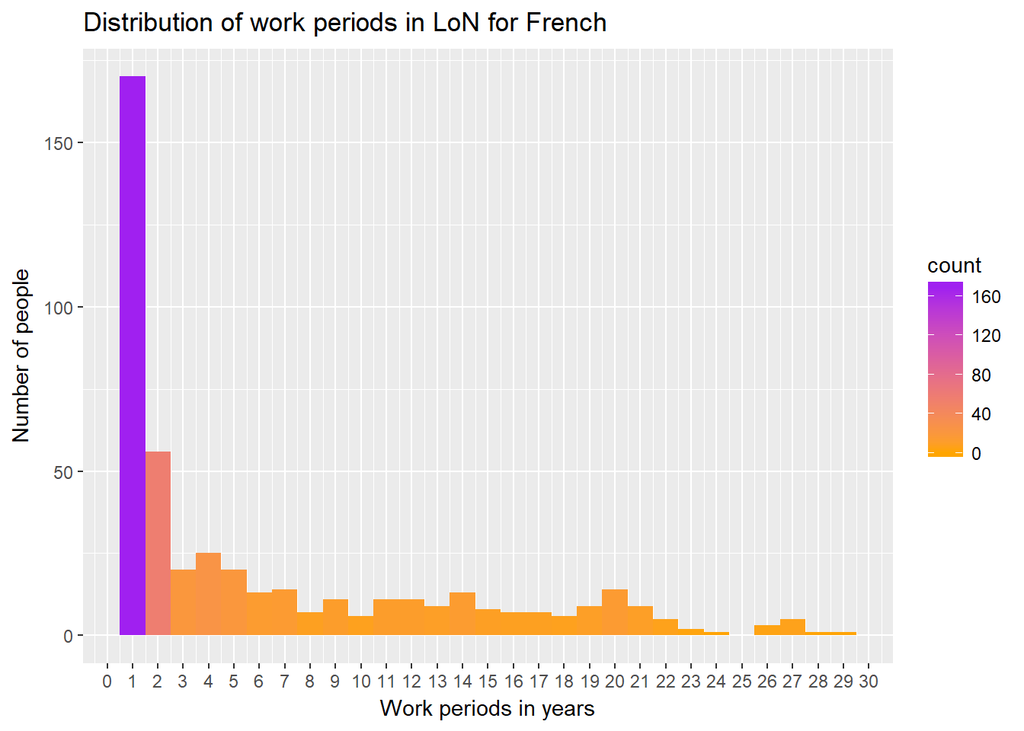

```r
employment_distribution(filter(five_nats, nationality == levels(nationality)[2]),xseq = seq(0,30,1), yseq = seq(0,1500,50), group = levels(five_nats$nationality)[2])
```

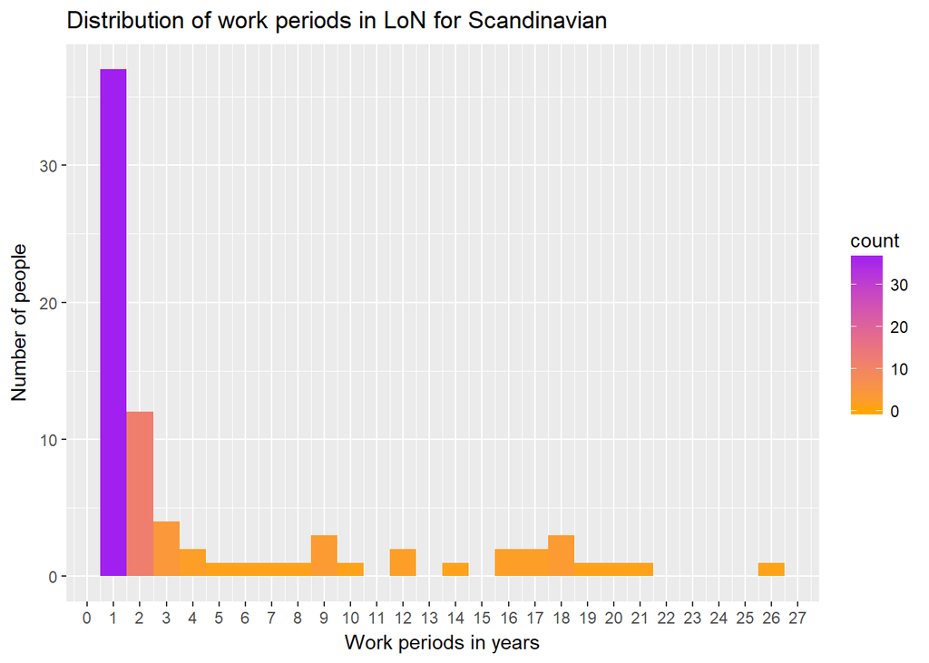

```r
employment_distribution(filter(five_nats, nationality == levels(nationality)[3]),xseq = seq(0,30,1), yseq = seq(0,1500,10), group = levels(five_nats$nationality)[3])
```

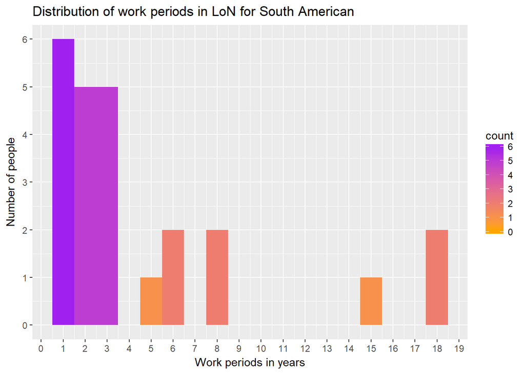

```r
employment_distribution(filter(five_nats, nationality == levels(nationality)[4]),xseq = seq(0,30,1), yseq = seq(0,1500,1), group = levels(five_nats$nationality)[4])
```

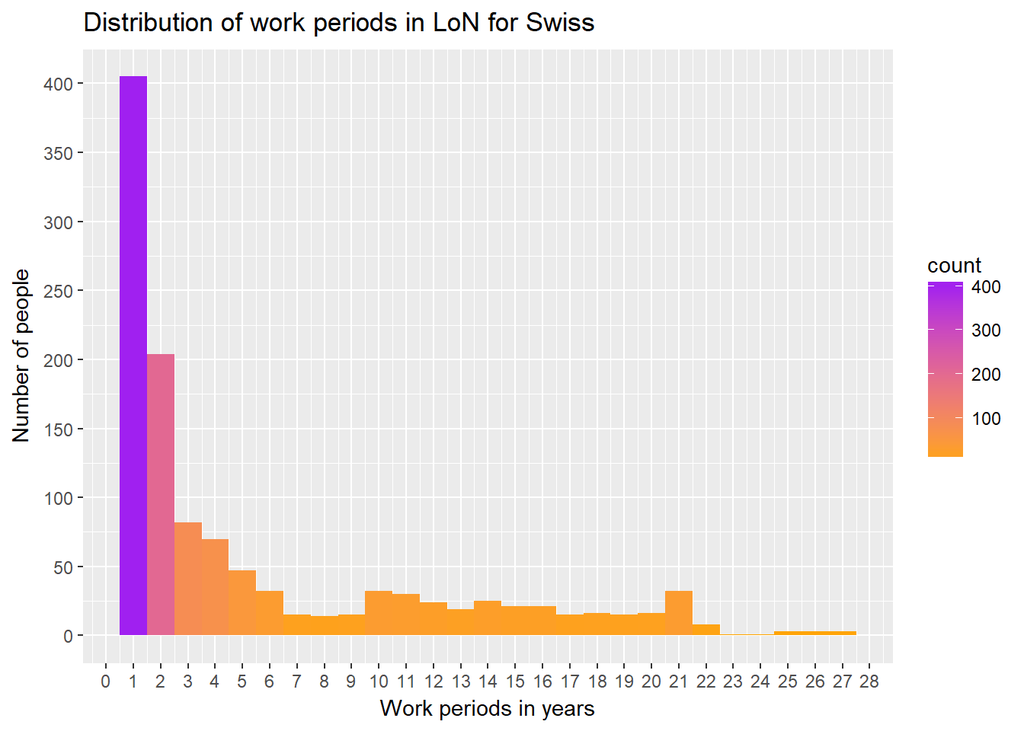

```r
employment_distribution(filter(five_nats, nationality == levels(nationality)[5]),xseq = seq(0,30,1), yseq = seq(0,1500,50), group = levels(five_nats$nationality)[5])
```

## New analysis: accumulated experience over time

Experience is interpret as the accumulated number of previous years workers have been in the league. This is plottet against the number of workers per year (this can ofc be changed).

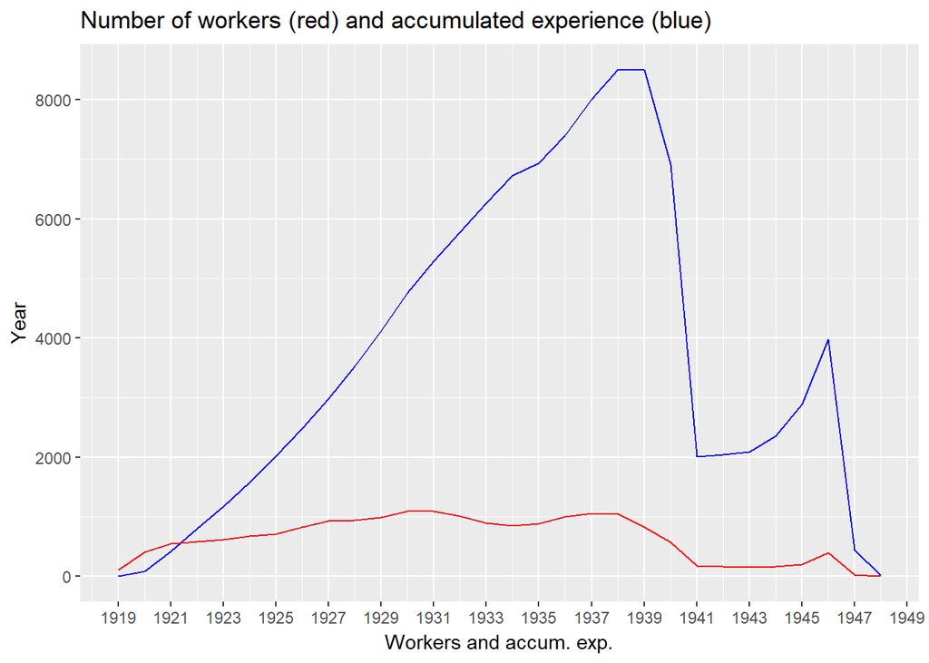

```r
#turn into function for later use
#employment_distribution <- function(df, yseq = seq(0,2000, 250), group = "people"){

  result <- employment(da)

  contract_length <- matrix(nrow = (nrow(result)), ncol = 1)

  result <- as.data.frame(result)

  names <- as.character(result[,1])

  wo_pname <- result[,-1]



  #starting a second year
  accumulated_experience <- matrix(NA, nrow = ncol(wo_pname))

  for (i in 2:ncol(wo_pname)){
    current_workers <- which(wo_pname[,i] != "")

    years_of_experience <- wo_pname[current_workers,1:(i-1)]%>%
      as.data.frame() %>%
  summarise_all(function(x) sum(x != "")) %>% sum

    accumulated_experience[i] = years_of_experience

  }

  worker <- wo_pname%>%
  summarise_all(function(x) sum(x != "")) %>%
    t %>%
    as.data.frame()


  accumulated_experience <- accumulated_experience %>%
    as.data.frame() %>%
    mutate(year = colnames(wo_pname),
           year = as.Date(year),
           nr_worker = worker$V1)
  accumulated_experience[1,1] = 0

accumulated_experience$nr_worker <- as.numeric(accumulated_experience$nr_worker)

accumulated_experience %>%
    ggplot(aes(x=year)) +
    geom_line(aes(y = V1), color = "blue")+
    geom_line(aes(y = nr_worker), color = "red") +
    scale_x_date(date_breaks = "2 years", date_labels = "%Y")+
    labs(x = "Workers and accum. exp.", y = "Year", title = "Number of workers (red) and accumulated experience (blue)")
```